# ProcessMining

```python
import pandas
import pm4py
import datetime as dt
import os
```

```python
import pandas as pd
event_log = pm4py.format_dataframe(pd.read_csv('C:/Users/ALI/Downloads/tamrins/running-example.csv', sep=';'), case_id='case_id',
activity_key='activity', timestamp_key='timestamp')
log = pm4py.read_xes('C:/Users/ALI/Downloads/tamrins/running-example.xes')
```

```python
log
```

```
[{'attributes': {'concept:name': '1'}, 'events': [{'concept:name': 'register request', 'time:timestamp': datetime.datetime(2010, 12, 30, 11, 2, tzinfo=datetime.timezone(datetime.timedelta(seconds=3600))), 'cost:total': 50, 'org:resource': 'Pete', '@@index': 14}, '..', {'concept:name': 'reject reques…
```

```python
event_log
```

|  | case_id | activity | timestamp | costs | resource | case:concept:name | concept:name | time:timestamp | @@index |
| --- | --- | --- | --- | --- | --- | --- | --- | --- | --- |
| 14 | 1 | register request | 2010-12-30 10:02:00+00:00 | 50 | Pete | 1 | register request | 2010-12-30 10:02:00+00:00 | 14 |
| 15 | 1 | examine thoroughly | 2010-12-31 09:06:00+00:00 | 400 | Sue | 1 | examine thoroughly | 2010-12-31 09:06:00+00:00 | 15 |
| 16 | 1 | check ticket | 2011-01-05 14:12:00+00:00 | 100 | Mike | 1 | check ticket | 2011-01-05 14:12:00+00:00 | 16 |
| 17 | 1 | decide | 2011-01-06 10:18:00+00:00 | 200 | Sara | 1 | decide | 2011-01-06 10:18:00+00:00 | 17 |
| 18 | 1 | reject request | 2011-01-07 13:24:00+00:00 | 200 | Pete | 1 | reject request | 2011-01-07 13:24:00+00:00 | 18 |
| 9 | 2 | register request | 2010-12-30 10:32:00+00:00 | 50 | Mike | 2 | register request | 2010-12-30 10:32:00+00:00 | 9 |
| 10 | 2 | check ticket | 2010-12-30 11:12:00+00:00 | 100 | Mike | 2 | check ticket | 2010-12-30 11:12:00+00:00 | 10 |
| 11 | 2 | examine casually | 2010-12-30 13:16:00+00:00 | 400 | Sean | 2 | examine casually | 2010-12-30 13:16:00+00:00 | 11 |
| 12 | 2 | decide | 2011-01-05 10:22:00+00:00 | 200 | Sara | 2 | decide | 2011-01-05 10:22:00+00:00 | 12 |
| 13 | 2 | pay compensation | 2011-01-08 11:05:00+00:00 | 200 | Ellen | 2 | pay compensation | 2011-01-08 11:05:00+00:00 | 13 |
| 0 | 3 | register request | 2010-12-30 13:32:00+00:00 | 50 | Pete | 3 | register request | 2010-12-30 13:32:00+00:00 | 0 |
| 1 | 3 | examine casually | 2010-12-30 14:06:00+00:00 | 400 | Mike | 3 | examine casually | 2010-12-30 14:06:00+00:00 | 1 |
| 2 | 3 | check ticket | 2010-12-30 15:34:00+00:00 | 100 | Ellen | 3 | check ticket | 2010-12-30 15:34:00+00:00 | 2 |
| 3 | 3 | decide | 2011-01-06 08:18:00+00:00 | 200 | Sara | 3 | decide | 2011-01-06 08:18:00+00:00 | 3 |
| 4 | 3 | reinitiate request | 2011-01-06 11:18:00+00:00 | 200 | Sara | 3 | reinitiate request | 2011-01-06 11:18:00+00:00 | 4 |
| 5 | 3 | examine thoroughly | 2011-01-06 12:06:00+00:00 | 400 | Sean | 3 | examine thoroughly | 2011-01-06 12:06:00+00:00 | 5 |
| 6 | 3 | check ticket | 2011-01-08 10:43:00+00:00 | 100 | Pete | 3 | check ticket | 2011-01-08 10:43:00+00:00 | 6 |
| 7 | 3 | decide | 2011-01-09 08:55:00+00:00 | 200 | Sara | 3 | decide | 2011-01-09 08:55:00+00:00 | 7 |
| 8 | 3 | pay compensation | 2011-01-15 09:45:00+00:00 | 200 | Ellen | 3 | pay compensation | 2011-01-15 09:45:00+00:00 | 8 |
| 37 | 4 | register request | 2011-01-06 14:02:00+00:00 | 50 | Pete | 4 | register request | 2011-01-06 14:02:00+00:00 | 37 |
| 38 | 4 | check ticket | 2011-01-07 11:06:00+00:00 | 100 | Mike | 4 | check ticket | 2011-01-07 11:06:00+00:00 | 38 |
| 39 | 4 | examine thoroughly | 2011-01-08 13:43:00+00:00 | 400 | Sean | 4 | examine thoroughly | 2011-01-08 13:43:00+00:00 | 39 |
| 40 | 4 | decide | 2011-01-09 11:02:00+00:00 | 200 | Sara | 4 | decide | 2011-01-09 11:02:00+00:00 | 40 |
| 41 | 4 | reject request | 2011-01-12 14:44:00+00:00 | 200 | Ellen | 4 | reject request | 2011-01-12 14:44:00+00:00 | 41 |
| 24 | 5 | register request | 2011-01-06 08:02:00+00:00 | 50 | Ellen | 5 | register request | 2011-01-06 08:02:00+00:00 | 24 |
| 25 | 5 | examine casually | 2011-01-07 09:16:00+00:00 | 400 | Mike | 5 | examine casually | 2011-01-07 09:16:00+00:00 | 25 |
| 26 | 5 | check ticket | 2011-01-08 10:22:00+00:00 | 100 | Pete | 5 | check ticket | 2011-01-08 10:22:00+00:00 | 26 |
| 27 | 5 | decide | 2011-01-10 12:28:00+00:00 | 200 | Sara | 5 | decide | 2011-01-10 12:28:00+00:00 | 27 |
| 28 | 5 | reinitiate request | 2011-01-11 15:18:00+00:00 | 200 | Sara | 5 | reinitiate request | 2011-01-11 15:18:00+00:00 | 28 |
| 29 | 5 | check ticket | 2011-01-14 13:33:00+00:00 | 100 | Ellen | 5 | check ticket | 2011-01-14 13:33:00+00:00 | 29 |
| 30 | 5 | examine casually | 2011-01-16 14:50:00+00:00 | 400 | Mike | 5 | examine casually | 2011-01-16 14:50:00+00:00 | 30 |
| 31 | 5 | decide | 2011-01-19 10:18:00+00:00 | 200 | Sara | 5 | decide | 2011-01-19 10:18:00+00:00 | 31 |
| 32 | 5 | reinitiate request | 2011-01-20 11:48:00+00:00 | 200 | Sara | 5 | reinitiate request | 2011-01-20 11:48:00+00:00 | 32 |
| 33 | 5 | examine casually | 2011-01-21 08:06:00+00:00 | 400 | Sue | 5 | examine casually | 2011-01-21 08:06:00+00:00 | 33 |
| 34 | 5 | check ticket | 2011-01-21 10:34:00+00:00 | 100 | Pete | 5 | check ticket | 2011-01-21 10:34:00+00:00 | 34 |
| 35 | 5 | decide | 2011-01-23 12:12:00+00:00 | 200 | Sara | 5 | decide | 2011-01-23 12:12:00+00:00 | 35 |
| 36 | 5 | reject request | 2011-01-24 13:56:00+00:00 | 200 | Mike | 5 | reject request | 2011-01-24 13:56:00+00:00 | 36 |
| 19 | 6 | register request | 2011-01-06 14:02:00+00:00 | 50 | Mike | 6 | register request | 2011-01-06 14:02:00+00:00 | 19 |
| 20 | 6 | examine casually | 2011-01-06 15:06:00+00:00 | 400 | Ellen | 6 | examine casually | 2011-01-06 15:06:00+00:00 | 20 |
| 21 | 6 | check ticket | 2011-01-07 15:22:00+00:00 | 100 | Mike | 6 | check ticket | 2011-01-07 15:22:00+00:00 | 21 |
| 22 | 6 | decide | 2011-01-07 15:52:00+00:00 | 200 | Sara | 6 | decide | 2011-01-07 15:52:00+00:00 | 22 |
| 23 | 6 | pay compensation | 2011-01-16 10:47:00+00:00 | 200 | Mike | 6 | pay compensation | 2011-01-16 10:47:00+00:00 | 23 |

```python
num_events = len(event_log)
num_cases = len(event_log.case_id.unique())
print("Number of events: {}\nNumber of cases: {}".format(num_events, num_cases))
```

```
Number of events: 42
Number of cases: 6
```

```python
filtered = pm4py.filter_start_activities(log, {'register request'})
filtered
```

```
[{'attributes': {'concept:name': '1'}, 'events': [{'concept:name': 'register request', 'time:timestamp': datetime.datetime(2010, 12, 30, 11, 2, tzinfo=datetime.timezone(datetime.timedelta(seconds=3600))), 'cost:total': 50, 'org:resource': 'Pete', '@@index': 14}, '..', {'concept:name': 'reject reques…
```

```python
filtered2 = pm4py.filter_end_activities(event_log, {'pay compensation'})
filtered2
```

|  | case_id | activity | timestamp | costs | resource | case:concept:name | concept:name | time:timestamp | @@index |
| --- | --- | --- | --- | --- | --- | --- | --- | --- | --- |
| 9 | 2 | register request | 2010-12-30 10:32:00+00:00 | 50 | Mike | 2 | register request | 2010-12-30 10:32:00+00:00 | 9 |
| 10 | 2 | check ticket | 2010-12-30 11:12:00+00:00 | 100 | Mike | 2 | check ticket | 2010-12-30 11:12:00+00:00 | 10 |
| 11 | 2 | examine casually | 2010-12-30 13:16:00+00:00 | 400 | Sean | 2 | examine casually | 2010-12-30 13:16:00+00:00 | 11 |
| 12 | 2 | decide | 2011-01-05 10:22:00+00:00 | 200 | Sara | 2 | decide | 2011-01-05 10:22:00+00:00 | 12 |
| 13 | 2 | pay compensation | 2011-01-08 11:05:00+00:00 | 200 | Ellen | 2 | pay compensation | 2011-01-08 11:05:00+00:00 | 13 |
| 0 | 3 | register request | 2010-12-30 13:32:00+00:00 | 50 | Pete | 3 | register request | 2010-12-30 13:32:00+00:00 | 0 |
| 1 | 3 | examine casually | 2010-12-30 14:06:00+00:00 | 400 | Mike | 3 | examine casually | 2010-12-30 14:06:00+00:00 | 1 |
| 2 | 3 | check ticket | 2010-12-30 15:34:00+00:00 | 100 | Ellen | 3 | check ticket | 2010-12-30 15:34:00+00:00 | 2 |
| 3 | 3 | decide | 2011-01-06 08:18:00+00:00 | 200 | Sara | 3 | decide | 2011-01-06 08:18:00+00:00 | 3 |
| 4 | 3 | reinitiate request | 2011-01-06 11:18:00+00:00 | 200 | Sara | 3 | reinitiate request | 2011-01-06 11:18:00+00:00 | 4 |
| 5 | 3 | examine thoroughly | 2011-01-06 12:06:00+00:00 | 400 | Sean | 3 | examine thoroughly | 2011-01-06 12:06:00+00:00 | 5 |
| 6 | 3 | check ticket | 2011-01-08 10:43:00+00:00 | 100 | Pete | 3 | check ticket | 2011-01-08 10:43:00+00:00 | 6 |
| 7 | 3 | decide | 2011-01-09 08:55:00+00:00 | 200 | Sara | 3 | decide | 2011-01-09 08:55:00+00:00 | 7 |
| 8 | 3 | pay compensation | 2011-01-15 09:45:00+00:00 | 200 | Ellen | 3 | pay compensation | 2011-01-15 09:45:00+00:00 | 8 |
| 19 | 6 | register request | 2011-01-06 14:02:00+00:00 | 50 | Mike | 6 | register request | 2011-01-06 14:02:00+00:00 | 19 |
| 20 | 6 | examine casually | 2011-01-06 15:06:00+00:00 | 400 | Ellen | 6 | examine casually | 2011-01-06 15:06:00+00:00 | 20 |
| 21 | 6 | check ticket | 2011-01-07 15:22:00+00:00 | 100 | Mike | 6 | check ticket | 2011-01-07 15:22:00+00:00 | 21 |
| 22 | 6 | decide | 2011-01-07 15:52:00+00:00 | 200 | Sara | 6 | decide | 2011-01-07 15:52:00+00:00 | 22 |
| 23 | 6 | pay compensation | 2011-01-16 10:47:00+00:00 | 200 | Mike | 6 | pay compensation | 2011-01-16 10:47:00+00:00 | 23 |

```python
filtered3 = pm4py.filter_variants(event_log, [
    ['register request', 'check ticket', 'examine casually', 'decide', 'pay compensation']])
filtered3
```

|  | case_id | activity | timestamp | costs | resource | case:concept:name | concept:name | time:timestamp | @@index |
| --- | --- | --- | --- | --- | --- | --- | --- | --- | --- |
| 9 | 2 | register request | 2010-12-30 10:32:00+00:00 | 50 | Mike | 2 | register request | 2010-12-30 10:32:00+00:00 | 9 |
| 10 | 2 | check ticket | 2010-12-30 11:12:00+00:00 | 100 | Mike | 2 | check ticket | 2010-12-30 11:12:00+00:00 | 10 |
| 11 | 2 | examine casually | 2010-12-30 13:16:00+00:00 | 400 | Sean | 2 | examine casually | 2010-12-30 13:16:00+00:00 | 11 |
| 12 | 2 | decide | 2011-01-05 10:22:00+00:00 | 200 | Sara | 2 | decide | 2011-01-05 10:22:00+00:00 | 12 |
| 13 | 2 | pay compensation | 2011-01-08 11:05:00+00:00 | 200 | Ellen | 2 | pay compensation | 2011-01-08 11:05:00+00:00 | 13 |

```python
filtered4 = pm4py.filter_time_range(event_log, dt.datetime(2010, 12, 30), dt.datetime(2010, 12, 31), mode='events')
filtered4
```

|  | case_id | activity | timestamp | costs | resource | case:concept:name | concept:name | time:timestamp | @@index |
| --- | --- | --- | --- | --- | --- | --- | --- | --- | --- |
| 14 | 1 | register request | 2010-12-30 10:02:00+00:00 | 50 | Pete | 1 | register request | 2010-12-30 10:02:00+00:00 | 14 |
| 9 | 2 | register request | 2010-12-30 10:32:00+00:00 | 50 | Mike | 2 | register request | 2010-12-30 10:32:00+00:00 | 9 |
| 10 | 2 | check ticket | 2010-12-30 11:12:00+00:00 | 100 | Mike | 2 | check ticket | 2010-12-30 11:12:00+00:00 | 10 |
| 11 | 2 | examine casually | 2010-12-30 13:16:00+00:00 | 400 | Sean | 2 | examine casually | 2010-12-30 13:16:00+00:00 | 11 |
| 0 | 3 | register request | 2010-12-30 13:32:00+00:00 | 50 | Pete | 3 | register request | 2010-12-30 13:32:00+00:00 | 0 |
| 1 | 3 | examine casually | 2010-12-30 14:06:00+00:00 | 400 | Mike | 3 | examine casually | 2010-12-30 14:06:00+00:00 | 1 |
| 2 | 3 | check ticket | 2010-12-30 15:34:00+00:00 | 100 | Ellen | 3 | check ticket | 2010-12-30 15:34:00+00:00 | 2 |

## Rework (activities)

The rework statistic permits to identify the activities which have been repeated during the same process execution. This shows the underlying inefficiencies in the process.

```python
rework = pm4py.get_rework_cases_per_activity(log)
rework
```

```
{'check ticket': 2,
 'decide': 2,
 'examine casually': 1,
 'reinitiate request': 1}
```

## Rework (cases)

We define as rework at the case level the number of events of a case having an activity which has appeared previously in the case. For example, if a case contains the following activities: A,B,A,B,C,D; the rework is 2 since the events in position 3 and 4 are referring to activities that have already been included previously.

```python
from pm4py.statistics.rework.cases.log import get as rework_cases

dictio = rework_cases.apply(log)
dictio
```

```
{'1': {'number_activities': 5, 'rework': 0},
 '2': {'number_activities': 5, 'rework': 0},
 '3': {'number_activities': 9, 'rework': 2},
 '4': {'number_activities': 5, 'rework': 0},
 '5': {'number_activities': 13, 'rework': 7},
 '6': {'number_activities': 5, 'rework': 0}}
```

### Distribution of case duratin

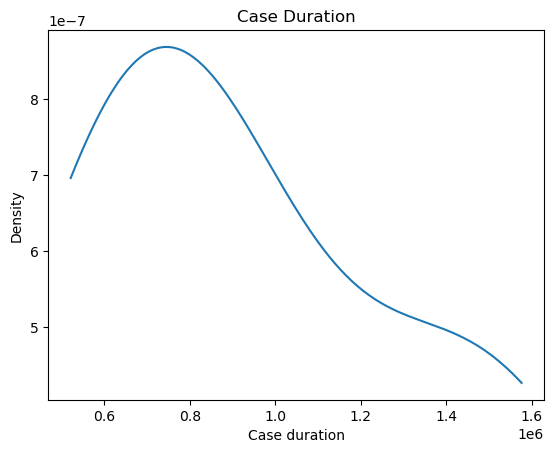

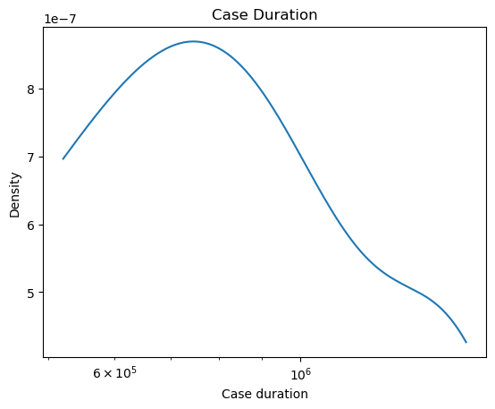

```python
log = xes_importer.apply(log_path)

from pm4py.util import constants
from pm4py.statistics.traces.generic.log import case_statistics
x, y = case_statistics.get_kde_caseduration(log, parameters={constants.PARAMETER_CONSTANT_TIMESTAMP_KEY: "time:timestamp"})

from pm4py.visualization.graphs import visualizer as graphs_visualizer

gviz = graphs_visualizer.apply_plot(x, y, variant=graphs_visualizer.Variants.CASES)
graphs_visualizer.view(gviz)

gviz = graphs_visualizer.apply_semilogx(x, y, variant=graphs_visualizer.Variants.CASES)
graphs_visualizer.view(gviz)
```

### Distribution of events over time

In the following example, a graph representing the distribution of events over time is obtained. This is particularly important because it helps to understand in which time intervals the greatest number of events is recorded. The distribution related to events over time may be obtained. The graph could be obtained.

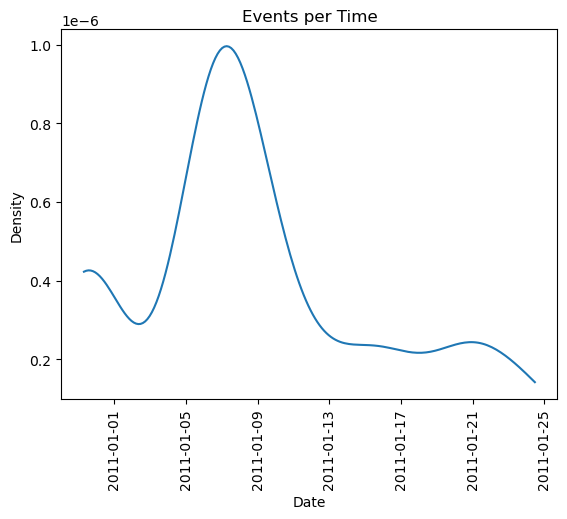

```python
from pm4py.algo.filtering.log.attributes import attributes_filter

x, y = attributes_filter.get_kde_date_attribute(log, attribute="time:timestamp")

from pm4py.visualization.graphs import visualizer as graphs_visualizer

gviz = graphs_visualizer.apply_plot(x, y, variant=graphs_visualizer.Variants.DATES)
graphs_visualizer.view(gviz)
```

### Alpha Miner

The alpha miner is one of the most known Process Discovery algorithm

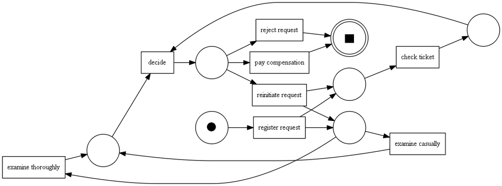

```python
import os
from pm4py.objects.log.importer.xes import importer as xes_importer

log = xes_importer.apply(os.path.join("tests","input_data","C:/Users/ALI/Downloads/tamrins/running-example.xes"))

from pm4py.algo.discovery.alpha import algorithm as alpha_miner
net, initial_marking, final_marking = alpha_miner.apply(log)

from pm4py.visualization.petri_net import visualizer as pn_visualizer
gviz = pn_visualizer.apply(net, initial_marking, final_marking)
pn_visualizer.view(gviz)
```

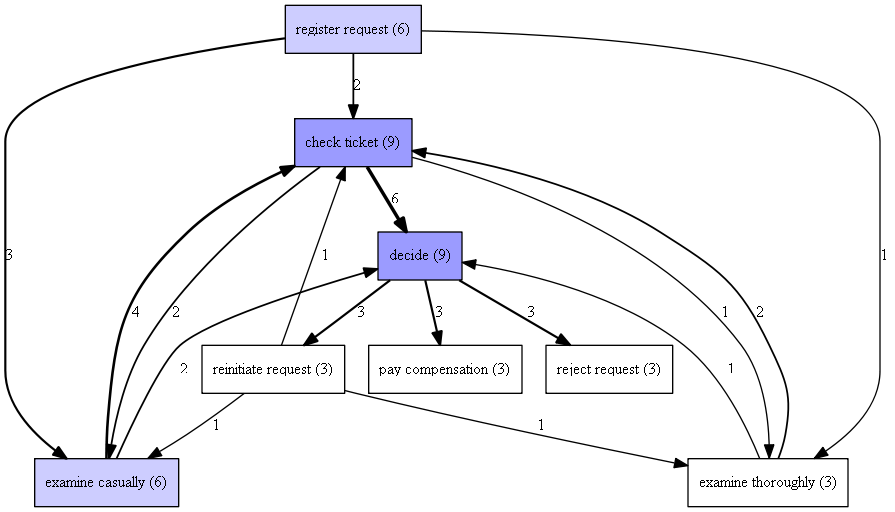

```python
import os
from pm4py.objects.log.importer.xes import importer as xes_importer
log = xes_importer.apply(os.path.join("tests","input_data","C:/Users/ALI/Downloads/tamrins/running-example.xes"))

from pm4py.algo.discovery.dfg import algorithm as dfg_discovery
dfg = dfg_discovery.apply(log)

from pm4py.visualization.dfg import visualizer as dfg_visualization
gviz = dfg_visualization.apply(dfg, log=log, variant=dfg_visualization.Variants.FREQUENCY)
dfg_visualization.view(gviz)
```

```python
import os
from pm4py.objects.log.importer.xes import importer as xes_importer

log = xes_importer.apply(os.path.join("tests","input_data","C:/Users/ALI/Downloads/tamrins/running-example.xes"))

from pm4py.algo.discovery.alpha import algorithm as alpha_miner
net, initial_marking, final_marking = alpha_miner.apply(log)
from pm4py.visualization.petri_net import visualizer as pn_visualizer
parameters = {pn_visualizer.Variants.FREQUENCY.value.Parameters.FORMAT: "png"}
gviz = pn_visualizer.apply(net, initial_marking, final_marking, parameters=parameters, variant=pn_visualizer.Variants.FREQUENCY, log=log)
pn_visualizer.save(gviz, "inductive_frequency.png")
```

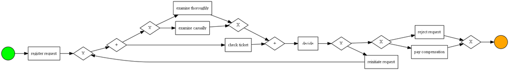

```python
#Figure 6: BPMN model discovered based on the running example event data set, using the Inductive Miner implementation of PM4Py.
process_tree = pm4py.discover_process_tree_inductive(event_log)
bpmn_model = pm4py.convert_to_bpmn(process_tree)
pm4py.view_bpmn(bpmn_model)
```

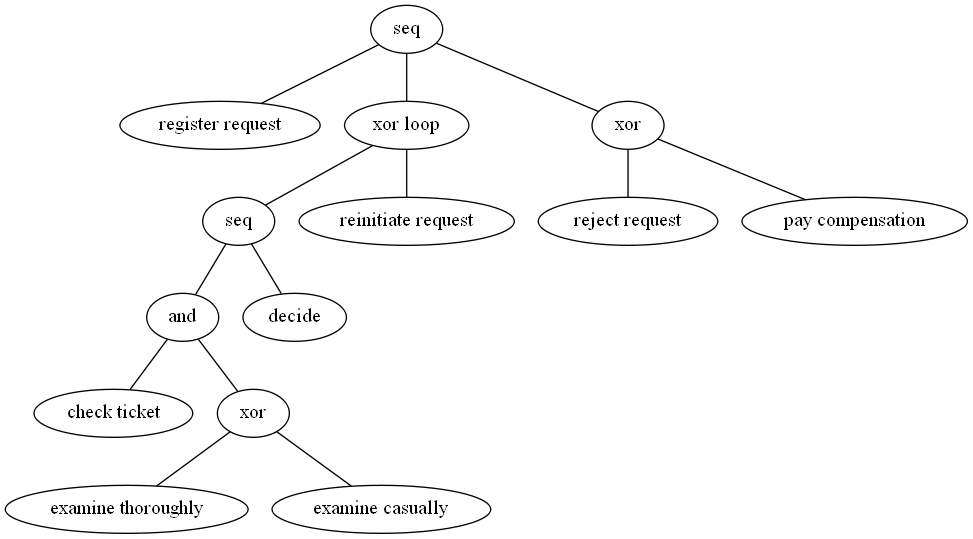

```python
#Figure 7: Process Tree model discovered based on the running example event data set, using the Inductive Miner implementation of PM4Py.
process_tree = pm4py.discover_process_tree_inductive(log)
pm4py.view_process_tree(process_tree)
```

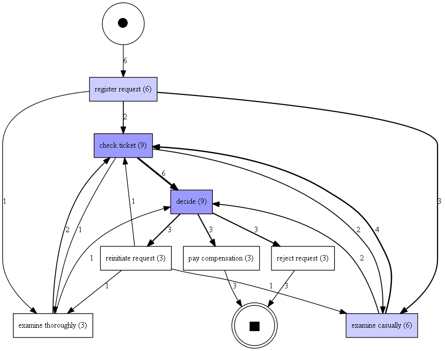

```python
#Figure 8: Process Map (DFG-based) discovered based on the running example event data set.

dfg, start_activities, end_activities = pm4py.discover_dfg(log)
pm4py.view_dfg(dfg, start_activities, end_activities)
```

### Decision Mining

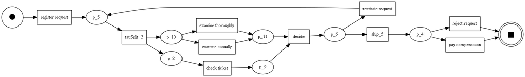

```python
#Calculating a model using the inductive miner:
from pm4py.algo.discovery.inductive import algorithm as inductive_miner

net, im, fm = inductive_miner.apply(log)

#A visualization of the model can be obtained in the following way:
from pm4py.visualization.petri_net import visualizer

gviz = visualizer.apply(net, im, fm, parameters={visualizer.Variants.WO_DECORATION.value.Parameters.DEBUG: True})
visualizer.view(gviz)
```

### Decision tree

We provide a function to automate the discovery of decision trees out of the decision mining technique.

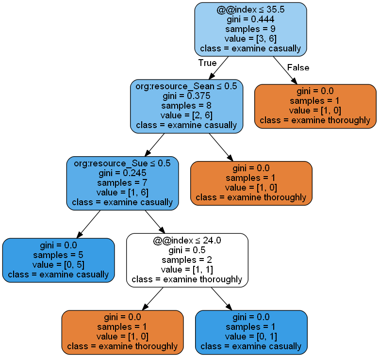

```python
from pm4py.algo.decision_mining import algorithm as decision_mining

clf, feature_names, classes = decision_mining.get_decision_tree(log, net, im, fm, decision_point="p_10")
from pm4py.visualization.decisiontree import visualizer as tree_visualizer

gviz = tree_visualizer.apply(clf, feature_names, classes)
visualizer.view(gviz)
```

ali8asgari@gmail.com